# Computational Methods for Qualitative Research in Criminology and Criminal Justice Studies

This article supplement, intended as a pedagogical tool, provides all of the code necessary to reproduce the case study illustration in *Computational Methods for Qualitative Research in Criminology and Criminal Justice Studies* (work in progress). To boost the pedagogical value of this resource, we have provided detailed explanations and commentaries throughout each step.

# Collecting

### Website Recon

[figure not shown]

### Index Scrape

The first step we took in our index scrape was to create a file (a csv file), on our local computer, that would store the results of our scrape. This is not the only way to do this, but is the way that we find to be most efficient. Another way to do this would be to store the results in the RStudio’s global environment, saving the results to your local computer after the scrape completes. Two major downsides to this approach are (1) you cannot see the results of the scrape until the scrape is completed; (2) if your scrape fails at some point (which it very likely will, especially on longer scrapes), you’ll lose the results you had obtained up to that point. So, let’s start by creating a csv spreadsheet that contains named columns for the data we’ll be collecting (headline_url, headline_text, etc.) in our index scrape. To do this we’ll use the library(tibble) and library(readr).

```r
#install.packages("tibble")
#install.packages("readr")
library(tibble)
library(readr)
```

```r
# give the file you'll be creating a name
filename <- "rcmp-news-index-scrape.csv"

# using the tibble function, create a dataframe with column headers
create_data <- function(
    headline_url = NA,
    headline_text = NA,
    date_published = NA,
    metadata_text = NA,
    page_url = NA
  ) {
    tibble(
        headline_url = headline_url,
        headline_text = headline_text,
        date_published = date_published,
        metadata_text = metadata_text,
        page_url = page_url
    )
  }

# write tibble to csv
write_csv(create_data() %>% drop_na(), filename, append = TRUE, col_names = TRUE)
```

Next, let’s write the code for our index scraping algorithm, which will obtain the data from the RCMP’s website and populate the csv file we just created in the last chunk of code. We’ll need an additional library to do this – library(rvest) – which will be used to get and parse the data from the RCMP’s website. To locate the information we want in the HTML, we’ll be specifying the html element that embeds the content we are interested in obtaining (link to full article, date, headline text, etc.). Obtaining these elements is a bit of art. There are [developer tools](https://developer.mozilla.org/en-US/docs/Learn/Common_questions/What_are_browser_developer_tools) built into every browser to easily obtain them. Another popular way of obtaining them is via the browser plug in “[selector gadget](https://selectorgadget.com/)”.

```r
#install.packages("rvest")
#install.packages("glue")
library(rvest)
library(glue)
```

```r
base_url <- 'https://www.rcmp-grc.gc.ca/en/news?page='

max_page_num <- NA # note that these pages are zero-indexed

scrape_page <- function(page_num = 0) {

  # grab html only once
  page_url <- paste(base_url, page_num, sep = '')

  curr_page <- read_html(page_url)

  # zero in on news list
  news_list <- curr_page %>%
    html_node('.list-group')

  # grab headline nodes
  headline_nodes <- news_list %>%
    html_nodes('div > div > a')

  # use headline nodes to get urls
  headline_url <- headline_nodes %>%
    html_attr('href') %>%
    url_absolute('https://www.rcmp-grc.gc.ca/en/news')

  # use headline nodes to get text
  headline_text <- headline_nodes %>%
    html_text(trim = TRUE)

  # grab metadata field
  metadata <- news_list %>%
    html_nodes('div > div > span.text-muted')

  # use metadata field to grab pubdate
  date_published <- metadata %>%
    html_nodes('meta[itemprop=datePublished]') %>%
    html_attr('content')

  # use metadata field to grab metadata text
  metadata_text <- metadata %>%
    html_text(trim = TRUE)

  # build a tibble
  page_data <- create_data(
    headline_url = headline_url,
    headline_text = headline_text,
    date_published = date_published,
    metadata_text = metadata_text,
    page_url = page_url,
    scrape_time = now()
  )

  # write to csv
  write_csv(page_data, filename, append = TRUE)

  max_page <- page_data %>%
    html_node('div.contextual-links-region ul.pagination li:nth-last-child(2)') %>%
    html_text(trim = TRUE) %>%
    as.numeric() %>%
    -(1)

  max_page_num <- max_page

  Sys.sleep(3)

  # recur
  if ((page_num + 1) <= max_page_num) {
    scrape_page(page_num = page_num + 1)
  }

}

# run it once
scrape_page()
```

#### Save results of index scrape

```r
index <- read_csv("rcmp-news-index-scrape.csv")

index_list <- as.list(index$headline_url)

sleep_interval <- 3

filename <- 'rcmp-news-text-scrape.csv'

create_data <- function(
  headline_url = NA,
  full_text = NA,
  scrape_time = NA
) {
  tibble(
    headline_url = headline_url,
    full_text = full_text
  ) %>%
    mutate(
      scrape_time = scrape_time
    )
}

# write once to create headers
write_csv(create_data() %>% drop_na(), filename, append = TRUE, col_names = TRUE)

lapply(index_list, function(i) {

  print(glue('Scraping page {i}…'))

  webpage <- read_html(i)

  node <- html_node(webpage, ".node-news-release > div")

  main_text <- html_text(node, trim = TRUE)

  print(main_text)

  currdata <- create_data(
    headline_url = i,
    full_text = main_text,
    scrape_time = now()
  )

  write_csv(currdata, filename, append = TRUE)

  Sys.sleep(sleep_interval)

})
```

# Parsing, Cleaning, and Exploring

```r
rcmp_news <- read_csv(here::here("rcmp-news-df.csv"))
```

Let’s take a look at the results our DataFrame so far. For this we can use the `head()` function from base R to view only the first 6 rows of each variable.

```r
#install.packages("rmarkdown")
library(rmarkdown)
```

```r
paged_table(head(rcmp_news))
```

| headline_url | headline_text | date_published | region | full_text | image_url |
| --- | --- | --- | --- | --- | --- |
| https://www.rcmp-grc.gc.ca/en/news/2020/iqaluit-rcmp-body-worn-camera-pilot-start-november-30-2020 | Iqaluit RCMP Body-Worn Camera Pilot to start on November 30, 2020 | 2020-11-27 21:30:00 | Iqaluit, Nunavut | Nunavut RCMP would like to remind residents, starting this Monday November 30, 2020, some officers in Iqaluit Detachment will, be equipped with body-worn-cameras (BWC) while attending calls for servic… | NA |
| https://www.rcmp-grc.gc.ca/en/news/2020/dauphin-rcmp-looking-missing-girl | Update - Dauphin RCMP looking for missing girl | 2020-11-27 21:00:00 | Dauphin, Manitoba | Ashlyn Stobbe has been safely located. The RCMP thanks the public and the media for their assistance. On November 24, 2020, at approximately 1:30 am, Dauphin RCMP received a report of a missing 14-yea… | NA |
| https://www.rcmp-grc.gc.ca/en/news/2020/eastern-alberta-district-general-investigation-section-arrest-three-atm-thefts | Eastern Alberta District General Investigation Section arrest three for ATM thefts | 2020-11-27 20:45:00 | Westlock, Alberta | During the evening of Nov. 16, 2020, at approximately 11 p.m., the Eastern Alberta District General Investigation Section (EADGIS) with the assistance of the Westlock RCMP initiated a pursuit with a m… | https://www.rcmp-grc.gc.ca/sites/default/files/styles/cropped_small/public/news-nouvelles/2020-11-27/k_-_strat_comms_-_eastern_alberta_district_general_investigation_section_arrest_three_for_atm_theft… |
| https://www.rcmp-grc.gc.ca/en/news/2020/two-people-arrested-drugs-firearms-and-money-seized | Two people arrested; drugs, firearms and money seized | 2020-11-27 19:15:00 | Fredericton, New Brunswick | A coordinated law enforcement investigation has resulted in the seizure of drugs and firearms, and the arrests of two men in Fredericton, N.B. On November 26, 2020, at approximately 2:30 p.m., members… | https://www.rcmp-grc.gc.ca/sites/default/files/styles/cropped_small/public/news-nouvelles/2020-11-27/cdsa_warrant_fredericton_2020-11-26.jpg?sc=8ccb769526ebf228bd511362003281f3 |
| https://www.rcmp-grc.gc.ca/en/news/2020/maidstone-rcmp-six-policing-partners-collaborated-track-and-arrest-gang-associates-a-car | Maidstone RCMP: Six policing partners collaborated to track and arrest gang associates following a car theft | 2020-11-27 19:00:00 | Maidstone, Saskatchewan | Last Friday, officers from six policing partners rapidly coordinated their resources to track a stolen car in western Saskatchewan through an area of approximately 150 kilometres. The track culminated… | https://www.rcmp-grc.gc.ca/sites/default/files/styles/cropped_small/public/news-nouvelles/2020-11-27/skrcmp2020_maidstone_seized_items.jpg?sc=c27a97ce9354d88dbc6f040c3dab30cb |
| https://www.rcmp-grc.gc.ca/en/news/2020/update-charges-laid-fatal-single-vehicle-collision | Update: Charges laid in fatal single vehicle collision | 2020-11-27 18:45:00 | Eskasoni, Nova Scotia | The RCMP have charged an Eskasoni man following a fatal single vehicle collision that happened early Thursday morning. Yesterday just after 1 a.m., Eskasoni RCMP received a call of an impaired driver … | NA |

Inspecting the **region** variable, we can see that both the city/town/county and province/territory are grouped together and separated by a “,”. For example, on the first row, we have “Iqaluit, Nunavut”, and one the second row, we have “Dauphin, Manitoba”. As it is going to be useful for our analysis to explore pattern in the data by province/territory, we will want to split the **region** variable so that we have two variables instead, one that contains the town/city/county information, and one that contains the province/territory information. We can achieve this using `separate()` function, which comes from library(tidyr). We will apply the `separate()` function to our region variable, saving the results of our DataFrame (rcmp_news) into a new DataFrame (rcmp_news_pp, where pp stands for “pre-processed”). The `separate()` function requires you to provide the names of the new variables you’ll be creating (i.e., what the information on the left and right of the “,” will be saved into). We will call these “region1” (town/city/county) and “region2” (province/territory).

```r
#install.packages("tidyr")
library(tidyr)
```

```r
rcmp_news_pp <- rcmp_news %>%
  separate(region, c("region1", "region2"), sep = ", ")

paged_table(head(rcmp_news_pp, n = 200)) #inspect the results, again using the head() function, but this time let's inspect the first 200 results
```

| headline_url | headline_text | date_published | region1 | region2 | full_text | image_url |
| --- | --- | --- | --- | --- | --- | --- |
| https://www.rcmp-grc.gc.ca/en/news/2020/iqaluit-rcmp-body-worn-camera-pilot-start-november-30-2020 | Iqaluit RCMP Body-Worn Camera Pilot to start on November 30, 2020 | 2020-11-27 21:30:00 | Iqaluit | Nunavut | Nunavut RCMP would like to remind residents, starting this Monday November 30, 2020, some officers in Iqaluit Detachment will, be equipped with body-worn-cameras (BWC) while attending calls for servic… | NA |
| https://www.rcmp-grc.gc.ca/en/news/2020/dauphin-rcmp-looking-missing-girl | Update - Dauphin RCMP looking for missing girl | 2020-11-27 21:00:00 | Dauphin | Manitoba | Ashlyn Stobbe has been safely located. The RCMP thanks the public and the media for their assistance. On November 24, 2020, at approximately 1:30 am, Dauphin RCMP received a report of a missing 14-yea… | NA |
| https://www.rcmp-grc.gc.ca/en/news/2020/eastern-alberta-district-general-investigation-section-arrest-three-atm-thefts | Eastern Alberta District General Investigation Section arrest three for ATM thefts | 2020-11-27 20:45:00 | Westlock | Alberta | During the evening of Nov. 16, 2020, at approximately 11 p.m., the Eastern Alberta District General Investigation Section (EADGIS) with the assistance of the Westlock RCMP initiated a pursuit with a m… | https://www.rcmp-grc.gc.ca/sites/default/files/styles/cropped_small/public/news-nouvelles/2020-11-27/k_-_strat_comms_-_eastern_alberta_district_general_investigation_section_arrest_three_for_atm_theft… |
| https://www.rcmp-grc.gc.ca/en/news/2020/two-people-arrested-drugs-firearms-and-money-seized | Two people arrested; drugs, firearms and money seized | 2020-11-27 19:15:00 | Fredericton | New Brunswick | A coordinated law enforcement investigation has resulted in the seizure of drugs and firearms, and the arrests of two men in Fredericton, N.B. On November 26, 2020, at approximately 2:30 p.m., members… | https://www.rcmp-grc.gc.ca/sites/default/files/styles/cropped_small/public/news-nouvelles/2020-11-27/cdsa_warrant_fredericton_2020-11-26.jpg?sc=8ccb769526ebf228bd511362003281f3 |
| https://www.rcmp-grc.gc.ca/en/news/2020/maidstone-rcmp-six-policing-partners-collaborated-track-and-arrest-gang-associates-a-car | Maidstone RCMP: Six policing partners collaborated to track and arrest gang associates following a car theft | 2020-11-27 19:00:00 | Maidstone | Saskatchewan | Last Friday, officers from six policing partners rapidly coordinated their resources to track a stolen car in western Saskatchewan through an area of approximately 150 kilometres. The track culminated… | https://www.rcmp-grc.gc.ca/sites/default/files/styles/cropped_small/public/news-nouvelles/2020-11-27/skrcmp2020_maidstone_seized_items.jpg?sc=c27a97ce9354d88dbc6f040c3dab30cb |
| https://www.rcmp-grc.gc.ca/en/news/2020/update-charges-laid-fatal-single-vehicle-collision | Update: Charges laid in fatal single vehicle collision | 2020-11-27 18:45:00 | Eskasoni | Nova Scotia | The RCMP have charged an Eskasoni man following a fatal single vehicle collision that happened early Thursday morning. Yesterday just after 1 a.m., Eskasoni RCMP received a call of an impaired driver … | NA |
| https://www.rcmp-grc.gc.ca/en/news/2020/steinbach-rcmp-want-be-aware-public-health-orders | Steinbach RCMP want everyone to be aware of public health orders | 2020-11-27 18:15:00 | Steinbach | Manitoba | The Manitoba RCMP stresses that participating in any type of large gathering at this time is a contravention of the Public Health Orders currently in place by the Province of Manitoba. Contravening th… | NA |
| https://www.rcmp-grc.gc.ca/en/news/2020/whitehorse-man-arrested-child-pornography-charges | Whitehorse man arrested on child pornography charges | 2020-11-27 18:00:00 | Whitehorse | Yukon | Yukon RCMP received a report in Fall 2019 indicating that a person in Whitehorse had uploaded child pornography to a social media platform. Through investigation, the Yukon RCMP Internet Child Exploit… | NA |
| https://www.rcmp-grc.gc.ca/en/news/2020/missing-21-year-old-woman | Missing 21-year-old woman | 2020-11-27 17:45:00 | Geary | New Brunswick | The West District RCMP is asking for the public's assistance to help locate a missing 21-year-old woman from Geary, N.B. Shyla Horne was last seen on November 24, 2020, at approximately 8 p.m., at a h… | https://www.rcmp-grc.gc.ca/sites/default/files/styles/cropped_small/public/news-nouvelles/2020-11-27/missing_21-year-old_woman.png?sc=9d3305dfc33557f62d9e6a0fb165658f |
| https://www.rcmp-grc.gc.ca/en/news/2020/operation-corridor-enforcement-watson-lake-saw-multiple-violations | "Operation Corridor" enforcement in Watson Lake saw multiple violations | 2020-11-27 17:00:00 | Watson Lake | Yukon | This is a joint release between Yukon RCMP, Carrier Compliance and National Safety Code. Yukon RCMP Traffic Services along with enforcement officers from Yukon Highways and Public Works -Carrier Compl… | NA |

[output cut: 190 more lines]

Inspecting the first 200 results, we see that it *mostly* worked, until about page 14. On the second row of page 14, in the **region2** column, we can see that “Ontario Media advisory” has been entered where we expected the result to be just “Ontario”. Flipping through more of the pages, we see a similar labeling issue on page 18 (“Ontario NCR”, “Guysborough County”) and on page 19 (“Manitoba Statement”). At this stage we should ask: how many of the **region2** values contain information other than just the name of the province/territory? The easiest way to do this is to use the `count()` function from library(dplyr) to count the total number of times that each unique entry appears in the **region2** variable. From here we can print the results of our count in a table that we can manually inspect.

```r
#install.packges("dplyr")
library(dplyr)
```

```r
rcmp_region_count <- rcmp_news_pp %>%
  count(region2)

paged_table(rcmp_region_count)
```

| region2 | n |
| --- | --- |
| Alberta | 1280 |
| Alberta Depot | 6 |
| Alberta Media advisory | 1 |
| Alberta National | 2 |
| Alberta National Depot | 5 |
| Alberta National Statement | 1 |
| Alberta Statement | 13 |
| Alta | 1 |
| Alta. | 1 |
| Annapolis County | 18 |

[output cut: 124 more lines]

Paging through the elements in this table, we can see two problems: 1) there’s a lot of entries in the region2 variable that contain more or different information then the name of the province/territory; and 2) on the last page of the table, page 14, we see that there are 24 news releases in our corpus where the **region2** value is *NA*, meaning it is missing. This brings us to our first major cleaning operation: fixing the entries in our **region2** variable so that it only contains information on the province/territory of the RCMP detachment authoring the news release. To deal with this issue, we can write a custom function that re-labels each of the entries we want to re-label in region2. This is not the fastest nor most efficient way to achieve this result, but it is one of the easiest. (As this is a long chunk of code, we have hidden it from view. Click “Show code” to view.)

```r
recode_regions <- function(region) {
  case_when(
    region %in% c(
      "Ontario National",
      "Ontario Statement",
      "Ontario Media advisory",
      "Ontario NCR",
      "Ontario National Statement",
      "Ontario National Media advisory",
      "Ontario National NCR",
      "Ontario National Statement NCR",
      "Ontario National Speech",
      "Ontario Statement NCR",
      "Ontario Speech",
      "Ontario Media advisory NCR"
    ) ~ "Ontario",
    region %in% c(
      "Manitoba Statement",
      "Saskatchewan National Speech",
      "Saskatchewan National Depot",
      "Saskatchewan Statement Depot",
      "Saskatchewan Media advisory",
      "Saskatchewan Depot",
      "Saskatchewan Media advisory Depot",
      "Saskatchewan National",
      "Saskatchewan National Statement",
      "Maidstone",
      "Shaunavon",
      "Saskatchewan Statement",
      "Archerwill",
      "Lake Diefenbaker",
      "Pelican Narrows",
      "Moose Jaw",
      "Weyburn",
      "Southend",
      "Emma Lake",
      "Biggar",
      "Langenburg"
    ) ~ "Saskatchewan",
    region %in% c(
      "Quebec National Media advisory",
      "Quebec National",
      "Quebec Media advisory"
    ) ~ "Quebec",
    region %in% c(
      "Nova Scotia Media advisory",
      "Nova Scotia National",
      "Halifax Regional Municipality",
      "Nova Scotia Speech",
      "Nova Scotia Statement",
      "Nova Scotia National Speech",
      "Queens and Kings Counties",
      "Victoria County",
      "Digby County",
      "Hants County",
      "Kings County",
      "Kings and Prince Counties",
      "Annapolis County",
      "Colchester County",
      "Antigonish County",
      "Queens and King counties",
      "Inverness County",
      "Queens County",
      "Lunenburg County",
      "Yarmouth County",
      "Antigonish County",
      "Hanty County",
      "Cumberland County",
      "Shelburne County",
      "Richmond County",
      "Green Creek",
      "Coichester County",
      "Richmond Co.",
      "Guysborough County",
      "Pictou County",
      "Annapolis COunty",
      "Annapolis Valley",
      "Hants Co."
    ) ~ "Nova Scotia",
    region %in% c(
      "Manitoba Statement",
      "Manitoba National",
      "Manitoba ",
      "Manitoba Media advisory",
      "Rosebank"
    ) ~ "Manitoba",
    region %in% c(
      "PEI",
      "Queens and Kings Districts",
      "Queens and Kings counties",
      "Queens and Kings County"
    ) ~ "Prince Edward Island",
    region %in% c(
      "N.B. ",
      "N.B.",
      "New Brunswick Statement",
      "Aroostook and Oxbow",
      "New Brunswick Media advisory",
      "NB"
    ) ~ "New Brunswick",
    region %in% c(
      "Yukon Media advisory",
      "Carcross",
      "Yukon ",
      "Whitehorse",
      "Yukon Statement",
      "Ross River",
      "Haines Junction",
      "Faro"
    ) ~ "Yukon",
    region %in% c(
      "Alberta Statement",
      "Alberta National",
      "Alberta Media advisory",
      "Alta.",
      "Alta",
      "Alberta Depot",
      "Alberta National Depot",
      "Alberta National Statement",
      "Three Hills and Stettler"
    ) ~ "Alberta",
    region %in% c(
      "Newfoundland and Labrador Media advisory",
      "Newfoundland and Labrador Statement",
      "Nain",
      "Stephenville",
      "Deer Lake",
      "Hopedale",
      "Ferryland and Stephenville",
      "Grand Falls-Windsor",
      "Holyrood and Stephenville"
    ) ~ "Newfoundland and Labrador",
    region %in% c(
      "British Columbia National",
      "Green Lake"
    ) ~ "British Columbia",
    region %in% c(
      "Nunavut Media advisory"
    ) ~ "Nunavut",
    region %in% c(
      "Northwest Territories Media advisory"
    ) ~ "Northwest Territories",
    TRUE ~ region
  )
}
```

Next we will apply our cleaning function to to our DataFrame, using the `mutate()` function from library(dplyr). Before this, to deal with the 24 *NA* values we identified in **region2**, we are going to apply another dplyr function called `coalesce()`, which will move replace the *NA* values in region2 with the values from **region1**. We also going to add one additional step before applying our custom cleaning function. This will be to trim any unnecessary white space from the beginning and end of each entry in **region2**. To do this, we use the `str_trim()` function from library(stringr). Next, we’ll apply our cleaning function, after which we’ll inspect the results to see if it worked.

```r
#install.packages("stringr")
library(stringr)
```

```r
rcmp_news_pp <- rcmp_news_pp %>%
  mutate(region2 = coalesce(region2, region1)) %>%
  mutate(region2 = str_trim(region2)) %>%
  mutate(region2 = recode_regions(region2))

rcmp_region_count <- rcmp_news_pp %>%
  count(region2)

paged_table(rcmp_region_count)
```

| region2 | n |
| --- | --- |
| Alberta | 1311 |
| British Columbia | 2 |
| Manitoba | 1013 |
| New Brunswick | 2811 |
| Newfoundland and Labrador | 2399 |
| Northwest Territories | 631 |
| Nova Scotia | 3067 |
| Nunavut | 166 |
| Ontario | 386 |
| Prince Edward Island | 714 |

[output cut: 3 more lines]

It worked! Finally, let’s rename our **region1** and **region2** variables, calling them **town_city_county** and **prov_terr**. To this we can use the `rename()` function from library(dplyr).

```r
rcmp_news_pp <- rcmp_news_pp %>%
  rename(town_city_county = region1,
         prov_terr = region2)
```

Now that we’ve fixed our issues with the province/territory data in our DataFrame, we can begin to explore the corpus. A great technique for getting to know the data in your corpus is to use *data visualization*. Combining standard data manipulation and data visualization techniques like counting and bar graphs, we can easily visualize some of the more macro-level patterns in our corpus (publication of news releases over time, by province/territory, etc.). To do this, we’ll be using an R data visualization library called library(ggplot2). Since data often needs to be manipulated to some degree before visualization (e.g., counting the number of unique provinces/territories in the DataFrame, in order to create a bar chart visually representing the differences), we’ll also be using more of library(stringr) and library(dplyr). Let’s begin with a bar graph showing the total number of press releases in our corpus by province/territory. Note that to produce these graphs, we are going to use the theme aesthetics from library(hrbrthemes) and the default colour palette from library(fishualize), so you’ll need to install these two libraries first before you can run the code.

```r
#install.packages("ggplot2")
#install.packages("hrbrthemes")
#install.packages("fishualize")
library(ggplot2)
```

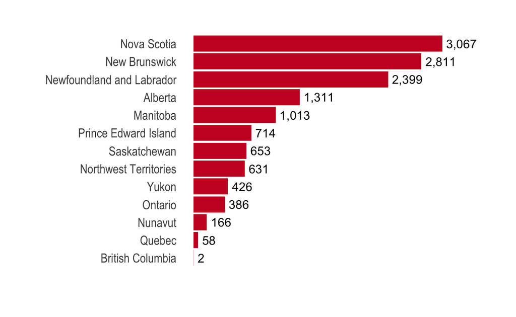

```r
rcmp_news_pp %>%
  group_by(prov_terr) %>%
  count(name = "count") %>%
  ggplot(aes(x = reorder(prov_terr, count), y = count)) +
  geom_col(fill = "#ca1928", show.legend = FALSE) +
  hrbrthemes::theme_ipsum(grid="") +
  theme(axis.text.x = element_blank()) +
  geom_text(aes(label=scales::comma(count)), hjust=0, nudge_y=50) +
  expand_limits(y = c(0, 3400)) +
  coord_flip() +
  labs(x = "", y = "")
```

Next, let’s look at the total proportion of news releases produced over time by province/territory. To calculate this, we are going to manipulate the date variable, removing information about day and time, in order to count the total number of news releases produced by each province/territory for each year-month combination (2016-05, 2016-06, 2016-07, etc.).

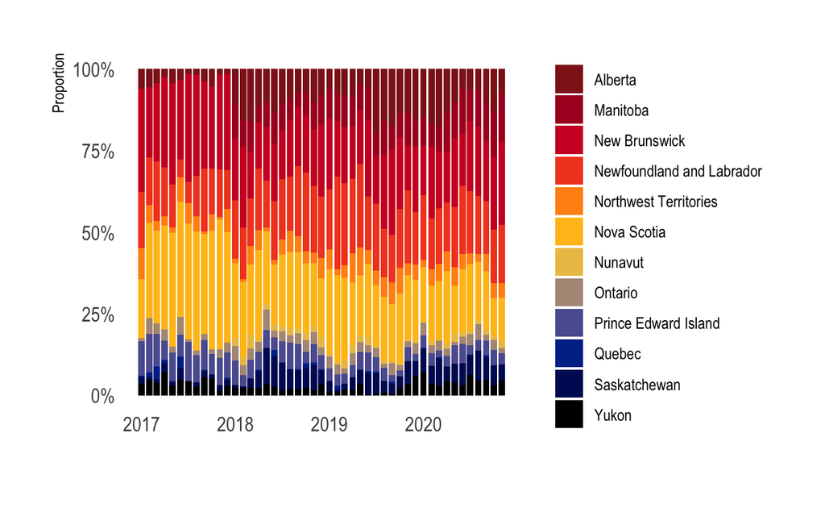

```r
rcmp_news_count <- rcmp_news_pp %>%
  filter(prov_terr != "British Columbia") %>%
  filter(!is.na(date_published)) %>%
  group_by(prov_terr, date_published) %>%
  mutate(date_published = str_remove_all(pattern= " (\\d{2})(\\:)(\\d{2})(\\:)(\\d{2})", date_published)) %>%
  mutate(date_published = as.Date(lubridate::ymd(date_published))) %>%
  count(name = "count", .drop = TRUE)

rcmp_news_count <- rcmp_news_count %>%
  mutate(date_published = format(date_published, "%Y-%m")) %>%
  mutate(date_published = paste(date_published, "-01", sep = "")) %>%
  mutate(date_published = as.Date(date_published, "%Y-%m-%d"))

rcmp_news_count <- rcmp_news_count %>%
  group_by(date_published, prov_terr) %>%
  summarize(count = sum(count)) %>%
  mutate(total = sum(count)) %>%
  mutate(prop = count/total) %>%
  filter(date_published != "2016-12-01")

rcmp_news_count %>%
  ggplot(aes(x = date_published, y = prop, fill = prov_terr)) +
  geom_col(position = "stack") +
  scale_y_continuous(labels = scales::percent_format()) +
  scale_x_date(breaks = as.Date(c("2017-01-01", "2018-01-01", "2019-01-01", "2020-01-01")), date_labels = "%Y") +
  fishualize::scale_fill_fish_d() +
  hrbrthemes::theme_ipsum(grid = "") +
  labs(y = "Proportion", x = "",
       fill = "")
```

Now let’s do the same thing with the raw count rather than the proportion.

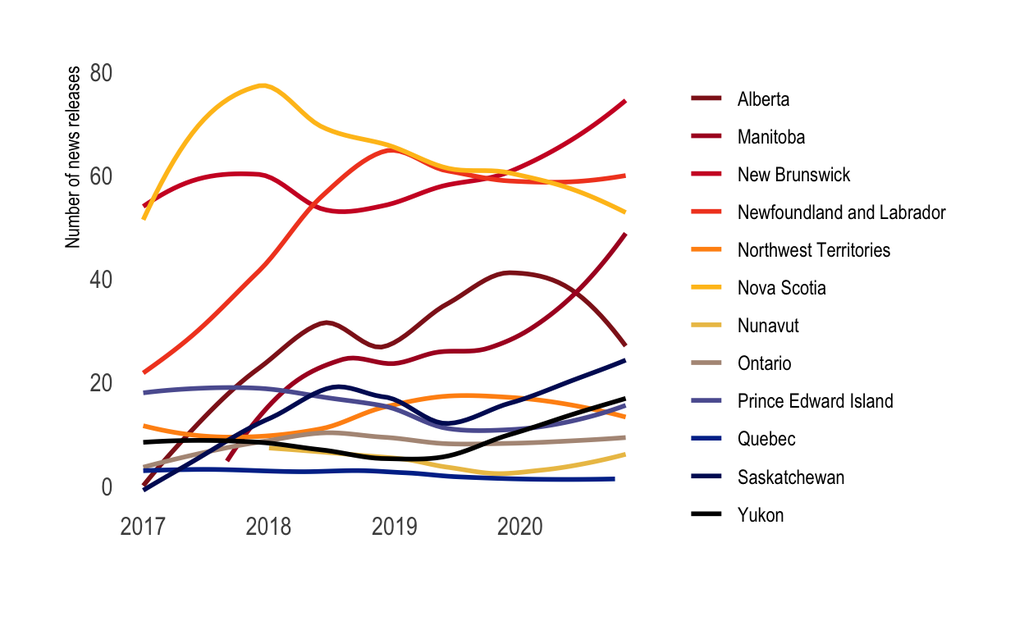

```r
rcmp_news_count %>%
  ggplot(aes(x = date_published, y = count, color = prov_terr)) +
  geom_smooth(se = FALSE) +
  scale_y_continuous() +
  scale_x_date(breaks = as.Date(c("2017-01-01", "2018-01-01", "2019-01-01", "2020-01-01")), date_labels = "%Y") +
  fishualize::scale_color_fish_d() +
  hrbrthemes::theme_ipsum(grid = "") +
  labs(y = "Number of news releases", x = "",
       color = "")
```

Finally, let’s look at the distribution of total word count across each of the news releases in our corpus, again by province/territory. To produce this particular graph, we are going to use the `geom_density_ridges()` function from library(ggridges), an add on to library(ggplot2).

```r
#install.packages("ggridges")
library(ggridges)
```

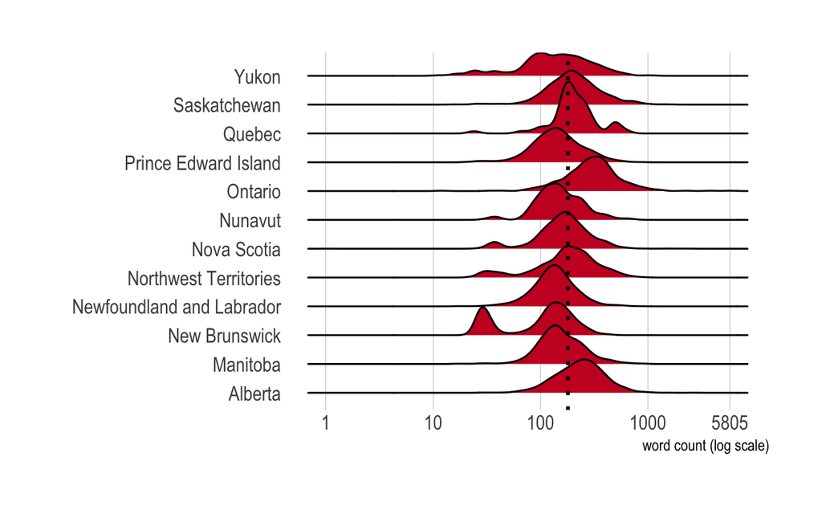

```r
rcmp_news_pp %>%
  filter(prov_terr != "British Columbia") %>%
  mutate(word_count = str_count(full_text, "\\w+")) %>%
  mutate(word_count_mean = mean(word_count, na.rm = TRUE)) %>%
  group_by(prov_terr) %>%
  ggplot(aes(x = word_count, y = prov_terr)) +
  geom_density_ridges(fill = "#ca1928", show.legend = FALSE) +
  geom_vline(aes(xintercept = word_count_mean), linetype="dotted", size = 1) +
  scale_x_log10(breaks = c(1, 10, 100, 1000, 5805)) +
  hrbrthemes::theme_ipsum(grid = "X") +
  labs(x = "word count (log scale)", y = "")
```

# Sampling and Outputting

As noted at the outset, we are interested in analyzing not only the textual component of our RCMP news corpus, but the visual component as well. The first question we might ask then is how many of the news releases actually contain images? To calculate this, we can create a table with four columns: one that indicates the province/territory of the RCMP detachment, one of the indicates the total number of news releases in the corpus, one of that indicates the total number of news releases in the corpus containing images, and finally, one that contains the percentage score of press releases taht contain images (for each province/territory). We can create this table using a number of helpful functions from library(dplyr), including `filter()` (to take out British Columbia), `add_count()` (to count the total number of press releases and the number of press releases containing images), and `mutate()` (to calculate the percentage score of news releases containing images), among others.

```r
table1 <- rcmp_news_pp %>%
  filter(prov_terr != "British Columbia") %>%
  group_by(prov_terr) %>%
  add_count(prov_terr, name = "total_press_releases") %>%
  add_count(image_url, name = "total_images") %>%
  summarize(total_press_releases = max(total_press_releases),
            total_images = max(total_images)) %>%
  mutate(proportion = round(total_images/total_press_releases*100, 2)) %>%
  select(prov_terr, total_press_releases, total_images, proportion) %>%
  arrange(desc(proportion)) %>%
  rename(`Province/Territory` = prov_terr,
         `Total NRs` = total_press_releases,
         `Total NRs w/ Images` = total_images,
         `Percent NRs w/ Images` = proportion) %>%
  ungroup()

paged_table(table1)
```

[output not shown]

```r
table2 <- rcmp_news_pp %>%
  filter(prov_terr != "British Columbia") %>%
  filter(!is.na(image_url),
         !is.na(full_text)) %>%
  group_by(prov_terr, image_url) %>%
  mutate(full_text = str_to_lower(full_text)) %>%
  count(tf = str_detect(full_text, my_pattern2)) %>%
  group_by(prov_terr, tf) %>%
  summarize(sum = sum(n)) %>%
  pivot_wider(names_from = tf, values_from = sum) %>%
  mutate(`FALSE` = `FALSE` + `TRUE`) %>%
  rename(`Total NRs w/ Images 2` = `TRUE`,
         `Total NRs 2` = `FALSE`,
         `Province/Territory` = prov_terr) %>%
  mutate(`Percent NRs w/ Images 2` = round(`Total NRs w/ Images 2`/`Total NRs 2`*100, 2)) %>%
  arrange(desc(`Percent NRs w/ Images 2`)) %>%
  ungroup()

paged_table(table2)
```

[output not shown]

```r
#install.packages("paletteer")
#install.packages("gt")
library(paletteer)
library(gt)
```

```r
table3 <- table1 %>%
  left_join(table2, by = c("Province/Territory" = "Province/Territory")) %>%
  rename(` ` = "Province/Territory")

table1 %>%
  gt() %>%
  #tab_spanner(label = "",
  #            columns = c(`Total NRs`, `Total NRs w/ Images`, `Percent NRs w/ Images`)) %>%
  data_color(
    columns = c(`Total NRs`, `Total NRs w/ Images`, `Percent NRs w/ Images`),
    colors = scales::col_numeric(
      paletteer::paletteer_d(
        palette = "ggsci::red_material")
        %>% as.character(),
      domain = NULL
      )
  )
```

[output not shown]

The subset corpus of 997 news releases (containing images) is a much more reasonably sized corpus to analyze. Although we may end up wanting to subset this corpus further, it is at very least a good place to start. What we want to do now is write some code that will: 1) create a DataFrame that contains only the values of our subset corpus; and 2) download each of the images and text data for the news releases. We can use metadata from the DataFrame to automatically name each of the images and corresponding text files, and put them into the same folder on our computer.

```r
#install.packages("splitstackshape")
library(splitstackshape)
```